# Project: Investigate a Dataset (TMDb_Movies Dataset)

- Introduction
- Data Wrangling
- Exploratory Data Analysis
- Conclusions

## Introduction

To complete my Data Analysis project I am using TMDb movies dataset.

This data set contains information about 10 thousand movies collected from The Movie Database (TMDb), including user ratings and revenue. It consist of 21 columns such as imdb_id, revenue, budget, vote_count etc.

#### Question that can analyised from this data set

1.Movies which had most and least profit

2.Movies with largest and lowest budgets

3.Movies with most and least earned revenue.

4.Movies with longest and shortest runtime values

5.Average runtime of all the movies, Popularity and Revenue.

6.In which year we had most no.of profitable movies.

7.Runtime of the most successful movies.

8.Successful genres (with respest to the profitable movies).

### Variables

Single variable analysis(1d exploration): Popularity, revenue, runtime over the time

Multiple variable analysis (2d exploration):Years of Release vs profitability, Revenue over time for the factors Popularity, Vote counts.

Any analysis conducted here is purely exploratory and any associations and inferences drawn are only tentative and are a basic step for conducting future analysis

### Resources

The resources i have used are DAND lessons , tutorials and DAND project resources

Resources from pandas libraries

Stackoverflow

```python
# Use this cell to set up import statements for all of the packages that you
#   plan to use.

# Remember to include a 'magic word' so that your visualizations are plotted
#   inline with the notebook. See this page for more:
#   http://ipython.readthedocs.io/en/stable/interactive/magics.html
#importing important files
import pandas as pd
import numpy as np
import csv
from datetime import datetime
import matplotlib.pyplot as plt
% matplotlib inline
```

## Data Wrangling

> In this section of the report, we will load in the data, check for cleanliness, and then trim and clean your dataset for analysis. Make sure that you document your steps carefully and justify your cleaning decisions. After observing the dataset and proposed questions for the analysis we will be keeping only relevent data deleting the unsued data so that we can make our calculation easy and understandable. .

### General Properties

```python
# Load your data and print out a few lines. Perform operations to inspect data
#   types and look for instances of missing or possibly errant data.
#loading the csv file and storing it in the variable "tmbd_data"
tmdb_data = pd.read_csv('tmdb-movies.csv')
#printing first five rows with defined columns of tmdb-movies database
tmdb_data.head(2)
```

|  | id | imdb_id | popularity | budget | revenue | original_title | cast | homepage | director | tagline | ... | overview | runtime | genres | production_companies | release_date | vote_count | vote_average | release_year | budget_adj | revenue_adj |
| --- | --- | --- | --- | --- | --- | --- | --- | --- | --- | --- | --- | --- | --- | --- | --- | --- | --- | --- | --- | --- | --- |
| 0 | 135397 | tt0369610 | 32.985763 | 150000000 | 1513528810 | Jurassic World | Chris Pratt\|Bryce Dallas Howard\|Irrfan Khan\|Vi... | http://www.jurassicworld.com/ | Colin Trevorrow | The park is open. | ... | Twenty-two years after the events of Jurassic ... | 124 | Action\|Adventure\|Science Fiction\|Thriller | Universal Studios\|Amblin Entertainment\|Legenda... | 6/9/15 | 5562 | 6.5 | 2015 | 1.379999e+08 | 1.392446e+09 |
| 1 | 76341 | tt1392190 | 28.419936 | 150000000 | 378436354 | Mad Max: Fury Road | Tom Hardy\|Charlize Theron\|Hugh Keays-Byrne\|Nic... | http://www.madmaxmovie.com/ | George Miller | What a Lovely Day. | ... | An apocalyptic story set in the furthest reach... | 120 | Action\|Adventure\|Science Fiction\|Thriller | Village Roadshow Pictures\|Kennedy Miller Produ... | 5/13/15 | 6185 | 7.1 | 2015 | 1.379999e+08 | 3.481613e+08 |

2 rows × 21 columns

#### Obsevations from the data set

1.) Unit of currency is missing in the dataset.I have taken dollar as it is the international unit of currency.

2.)Certain columns, like ‘cast’ and ‘genres’, contain multiple values separated by pipe (|) characters.

3.)Some Columns have 0s in the rows for example budget etc.

4.)Some odd characters in columns like original_title, cast etc.

5.) vote_count is different for all movies. So direct avg_count cannot be done to conclude the popularity of the movie.

### Data Cleaning (Removing the unused information from the dataset )

#### Important observation regarding this process

Removing duplicates

Removing the entries or discarding the entries with budget or revenues with 0 values in them since they are not useful for analysis

Replacing zero with NANS

Release date column into DateFormat

Formatting the budget and revenue columns with dollars

#### 1. Removing unused columns

```python
#creating a list of columb to be deleted
del_col=[ 'id', 'imdb_id',  'homepage', 'keywords', 'overview']
#deleting the columns
tmdb_data= tmdb_data.drop(del_col,1)

#previewing the new dataset
tmdb_data.head(5)
```

|  | popularity | budget | revenue | original_title | cast | director | tagline | runtime | genres | production_companies | release_date | vote_count | vote_average | release_year | budget_adj | revenue_adj |
| --- | --- | --- | --- | --- | --- | --- | --- | --- | --- | --- | --- | --- | --- | --- | --- | --- |
| 0 | 32.985763 | 150000000 | 1513528810 | Jurassic World | Chris Pratt\|Bryce Dallas Howard\|Irrfan Khan\|Vi... | Colin Trevorrow | The park is open. | 124 | Action\|Adventure\|Science Fiction\|Thriller | Universal Studios\|Amblin Entertainment\|Legenda... | 6/9/15 | 5562 | 6.5 | 2015 | 1.379999e+08 | 1.392446e+09 |
| 1 | 28.419936 | 150000000 | 378436354 | Mad Max: Fury Road | Tom Hardy\|Charlize Theron\|Hugh Keays-Byrne\|Nic... | George Miller | What a Lovely Day. | 120 | Action\|Adventure\|Science Fiction\|Thriller | Village Roadshow Pictures\|Kennedy Miller Produ... | 5/13/15 | 6185 | 7.1 | 2015 | 1.379999e+08 | 3.481613e+08 |
| 2 | 13.112507 | 110000000 | 295238201 | Insurgent | Shailene Woodley\|Theo James\|Kate Winslet\|Ansel... | Robert Schwentke | One Choice Can Destroy You | 119 | Adventure\|Science Fiction\|Thriller | Summit Entertainment\|Mandeville Films\|Red Wago... | 3/18/15 | 2480 | 6.3 | 2015 | 1.012000e+08 | 2.716190e+08 |
| 3 | 11.173104 | 200000000 | 2068178225 | Star Wars: The Force Awakens | Harrison Ford\|Mark Hamill\|Carrie Fisher\|Adam D... | J.J. Abrams | Every generation has a story. | 136 | Action\|Adventure\|Science Fiction\|Fantasy | Lucasfilm\|Truenorth Productions\|Bad Robot | 12/15/15 | 5292 | 7.5 | 2015 | 1.839999e+08 | 1.902723e+09 |
| 4 | 9.335014 | 190000000 | 1506249360 | Furious 7 | Vin Diesel\|Paul Walker\|Jason Statham\|Michelle ... | James Wan | Vengeance Hits Home | 137 | Action\|Crime\|Thriller | Universal Pictures\|Original Film\|Media Rights ... | 4/1/15 | 2947 | 7.3 | 2015 | 1.747999e+08 | 1.385749e+09 |

Finding out how many entries we have in the dataset

```python
rows, col = tmdb_data.shape
print('There are now {} total entries of movies and {} no.of columns in it.'.format(rows-1, col))
```

```
There are now 10865 total entries of movies and 16 no.of columns in it.
```

#### 3. Removing 0's from budget and the revenue columns -discard those entries

```python
# creating a seperate list of revenue and budget column
temp_list=['budget', 'revenue']

#this will replace all the value from '0' to NAN in the list
tmdb_data[temp_list] = tmdb_data[temp_list].replace(0, np.NAN)

#Removing all the row which has NaN value in temp_list
tmdb_data.dropna(subset = temp_list, inplace = True)
rows, col = tmdb_data.shape
print('So after removing such entries, we now have only {} no.of movies.'.format(rows-1))
```

```
So after removing such entries, we now have only 3854 no.of movies.
```

#### 4. Replacing zero with NAN in runtime column.

```python
#replacing 0 with NaN of runtime column in the dataset
tmdb_data['runtime'] =tmdb_data['runtime'].replace(0, np.NAN)
```

#### 5.Changing the release date column into standard date format

```python
tmdb_data.release_date = pd.to_datetime(tmdb_data['release_date'])
# printing the changed dataset
tmdb_data.head(3)
```

|  | popularity | budget | revenue | original_title | cast | director | tagline | runtime | genres | production_companies | release_date | vote_count | vote_average | release_year | budget_adj | revenue_adj |
| --- | --- | --- | --- | --- | --- | --- | --- | --- | --- | --- | --- | --- | --- | --- | --- | --- |
| 0 | 32.985763 | 150000000.0 | 1.513529e+09 | Jurassic World | Chris Pratt\|Bryce Dallas Howard\|Irrfan Khan\|Vi... | Colin Trevorrow | The park is open. | 124 | Action\|Adventure\|Science Fiction\|Thriller | Universal Studios\|Amblin Entertainment\|Legenda... | 2015-06-09 | 5562 | 6.5 | 2015 | 1.379999e+08 | 1.392446e+09 |
| 1 | 28.419936 | 150000000.0 | 3.784364e+08 | Mad Max: Fury Road | Tom Hardy\|Charlize Theron\|Hugh Keays-Byrne\|Nic... | George Miller | What a Lovely Day. | 120 | Action\|Adventure\|Science Fiction\|Thriller | Village Roadshow Pictures\|Kennedy Miller Produ... | 2015-05-13 | 6185 | 7.1 | 2015 | 1.379999e+08 | 3.481613e+08 |
| 2 | 13.112507 | 110000000.0 | 2.952382e+08 | Insurgent | Shailene Woodley\|Theo James\|Kate Winslet\|Ansel... | Robert Schwentke | One Choice Can Destroy You | 119 | Adventure\|Science Fiction\|Thriller | Summit Entertainment\|Mandeville Films\|Red Wago... | 2015-03-18 | 2480 | 6.3 | 2015 | 1.012000e+08 | 2.716190e+08 |

#### 6.. Changing format of budget and revenue column.

```python
#Checking the current format of columns in the dataset
#printing the data type of the data set
tmdb_data.dtypes
change_type=['budget', 'revenue']
#changing data type
tmdb_data[change_type]=tmdb_data[change_type].applymap(np.int64)
#printing the changed information
tmdb_data.dtypes
```

```
popularity                     float64
budget                           int64
revenue                          int64
original_title                  object
cast                            object
director                        object
tagline                         object
runtime                          int64
genres                          object
production_companies            object
release_date            datetime64[ns]
vote_count                       int64
vote_average                   float64
release_year                     int64
budget_adj                     float64
revenue_adj                    float64
dtype: object
```

## Exploratory Data Analysis

#### Let us create a profit column for all the movies

```python
# for creating a profit column we use insert function with column index position,name and value
tmdb_data.insert(2,'profit_earned',tmdb_data['revenue']-tmdb_data['budget'])
```

```python
#checking if the column is created
tmdb_data.head(2)
```

|  | popularity | budget | profit_earned | revenue | original_title | cast | director | tagline | runtime | genres | production_companies | release_date | vote_count | vote_average | release_year | budget_adj | revenue_adj |
| --- | --- | --- | --- | --- | --- | --- | --- | --- | --- | --- | --- | --- | --- | --- | --- | --- | --- |
| 0 | 32.985763 | 150000000 | 1363528810 | 1513528810 | Jurassic World | Chris Pratt\|Bryce Dallas Howard\|Irrfan Khan\|Vi... | Colin Trevorrow | The park is open. | 124 | Action\|Adventure\|Science Fiction\|Thriller | Universal Studios\|Amblin Entertainment\|Legenda... | 2015-06-09 | 5562 | 6.5 | 2015 | 1.379999e+08 | 1.392446e+09 |
| 1 | 28.419936 | 150000000 | 228436354 | 378436354 | Mad Max: Fury Road | Tom Hardy\|Charlize Theron\|Hugh Keays-Byrne\|Nic... | George Miller | What a Lovely Day. | 120 | Action\|Adventure\|Science Fiction\|Thriller | Village Roadshow Pictures\|Kennedy Miller Produ... | 2015-05-13 | 6185 | 7.1 | 2015 | 1.379999e+08 | 3.481613e+08 |

### creating a common Function to be accessed for calculating min and max of any column and return concatenated

```python
import pprint
#defining a calc function. THis is a common function that can be accessed across the notebook to calculate similar set of outcomes
def calc(column):

 #movie with highest profit
 max= tmdb_data[column].idxmax()
 #locating the entry with the highest profit value
 max_profit_movie=pd.DataFrame(tmdb_data.loc[max])

 #movie with lowest profit
 min= tmdb_data[column].idxmin()
 #locatiing the entry with lowest profit value
 min_profit_movie=pd.DataFrame(tmdb_data.loc[min])

 #combining the results
 details=pd.concat([max_profit_movie, min_profit_movie],1)
 return details
```

### Research Question 1 (Which movie had most profit and which movie had lowest profit )

```python
#function call
calc('profit_earned')
```

|  | 1386 | 2244 |
| --- | --- | --- |
| popularity | 9.43277 | 0.25054 |
| budget | 237000000 | 425000000 |
| profit_earned | 2544505847 | -413912431 |
| revenue | 2781505847 | 11087569 |
| original_title | Avatar | The Warrior's Way |
| cast | Sam Worthington\|Zoe Saldana\|Sigourney Weaver\|S... | Kate Bosworth\|Jang Dong-gun\|Geoffrey Rush\|Dann... |
| director | James Cameron | Sngmoo Lee |
| tagline | Enter the World of Pandora. | Assassin. Hero. Legend. |
| runtime | 162 | 100 |
| genres | Action\|Adventure\|Fantasy\|Science Fiction | Adventure\|Fantasy\|Action\|Western\|Thriller |
| production_companies | Ingenious Film Partners\|Twentieth Century Fox ... | Boram Entertainment Inc. |
| release_date | 2009-12-10 00:00:00 | 2010-12-02 00:00:00 |
| vote_count | 8458 | 74 |
| vote_average | 7.1 | 6.4 |
| release_year | 2009 | 2010 |
| budget_adj | 2.40887e+08 | 4.25e+08 |
| revenue_adj | 2.82712e+09 | 1.10876e+07 |

### Research Question 2 ( Movies with most and least earned revenue)

```python
# we will call the same function **calc(column)** again for this analysis
calc('revenue')
```

|  | 1386 | 5067 |
| --- | --- | --- |
| popularity | 9.43277 | 0.462609 |
| budget | 237000000 | 6000000 |
| profit_earned | 2544505847 | -5999998 |
| revenue | 2781505847 | 2 |
| original_title | Avatar | Shattered Glass |
| cast | Sam Worthington\|Zoe Saldana\|Sigourney Weaver\|S... | Hayden Christensen\|Peter Sarsgaard\|ChloÃ« Sevi... |
| director | James Cameron | Billy Ray |
| tagline | Enter the World of Pandora. | NaN |
| runtime | 162 | 94 |
| genres | Action\|Adventure\|Fantasy\|Science Fiction | Drama\|History |
| production_companies | Ingenious Film Partners\|Twentieth Century Fox ... | Lions Gate Films\|Cruise/Wagner Productions\|Bau... |
| release_date | 2009-12-10 00:00:00 | 2003-11-14 00:00:00 |
| vote_count | 8458 | 46 |
| vote_average | 7.1 | 6.4 |
| release_year | 2009 | 2003 |
| budget_adj | 2.40887e+08 | 7.11212e+06 |
| revenue_adj | 2.82712e+09 | 2.37071 |

Column with id 1386 shows the largest revenue earned i.e 2781505847 dollar.

Whereas the column with id 5067 shows the smallest revenue earned i.e 2 dollar

### Research Question 3 (Movies with largest and lowest budgets)

```python
# we will call the same function **calculate(column)** again for this analysis
calc('budget')
```

|  | 2244 | 2618 |
| --- | --- | --- |
| popularity | 0.25054 | 0.090186 |
| budget | 425000000 | 1 |
| profit_earned | -413912431 | 99 |
| revenue | 11087569 | 100 |
| original_title | The Warrior's Way | Lost & Found |
| cast | Kate Bosworth\|Jang Dong-gun\|Geoffrey Rush\|Dann... | David Spade\|Sophie Marceau\|Ever Carradine\|Step... |
| director | Sngmoo Lee | Jeff Pollack |
| tagline | Assassin. Hero. Legend. | A comedy about a guy who would do anything to ... |
| runtime | 100 | 95 |
| genres | Adventure\|Fantasy\|Action\|Western\|Thriller | Comedy\|Romance |
| production_companies | Boram Entertainment Inc. | Alcon Entertainment\|Dinamo Entertainment |
| release_date | 2010-12-02 00:00:00 | 1999-04-23 00:00:00 |
| vote_count | 74 | 14 |
| vote_average | 6.4 | 4.8 |
| release_year | 2010 | 1999 |
| budget_adj | 4.25e+08 | 1.30905 |
| revenue_adj | 1.10876e+07 | 130.905 |

Column with id 2244 shows the largest budget i.e 425000000 dollar.

Whereas the column with id 2618 shows the smallest budget i.e 1 dollar

### Research Question 4 ( Movies with longest and shortest runtime)

```python
# we will call the same function **calc(column)** again for this analysis
calc('runtime')
```

|  | 2107 | 5162 |
| --- | --- | --- |
| popularity | 0.534192 | 0.208637 |
| budget | 18000000 | 10 |
| profit_earned | -17128721 | -5 |
| revenue | 871279 | 5 |
| original_title | Carlos | Kid's Story |
| cast | Edgar Ramírez\|Alexander Scheer\|Fadi Abi Samra... | Clayton Watson\|Keanu Reeves\|Carrie-Anne Moss\|K... |
| director | Olivier Assayas | Shinichiro Watanabe |
| tagline | The man who hijacked the world | NaN |
| runtime | 338 | 15 |
| genres | Crime\|Drama\|Thriller\|History | Science Fiction\|Animation |
| production_companies | Egoli Tossell Film AG\|Canal+\|Arte France\|Films... | Studio 4°C |
| release_date | 2010-05-19 00:00:00 | 2003-06-02 00:00:00 |
| vote_count | 35 | 16 |
| vote_average | 6.2 | 6.8 |
| release_year | 2010 | 2003 |
| budget_adj | 1.8e+07 | 11.8535 |
| revenue_adj | 871279 | 5.92676 |

Column with id 2107 shows the longest runtime i.e 338 minutes.

Whereas the column with id 5162 shows the shortest runtime i.e 15 minutes

### Research Question 5 ( Average runtime , Popularity & Revenue of the movies)

```python
# defining a function to find average of any column
def avg_fun(column):
    return tmdb_data[column].mean()
#calling above function
avg_fun('runtime')
```

```
109.21582360570687
```

So the average runtime a movie is 109 minutes. Lets analyse it in a visual form i.e. by graphical approach.

### plotting a histogram for runtime of movies (1D Exploration)

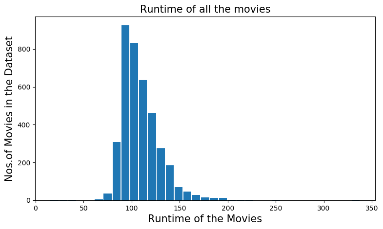

```python
#giving the figure size(width, height)
plt.figure(figsize=(9,5), dpi = 100)

#On x-axis
plt.xlabel('Runtime of the Movies', fontsize = 15)
#On y-axis
plt.ylabel('Nos.of Movies in the Dataset', fontsize=15)
#Name of the graph
plt.title('Runtime of all the movies', fontsize=15)

#giving a histogram plot
plt.hist(tmdb_data['runtime'], rwidth = 0.9, bins =35)
#displays the plot
plt.show()
```

### Analysing more about runtime using box plot

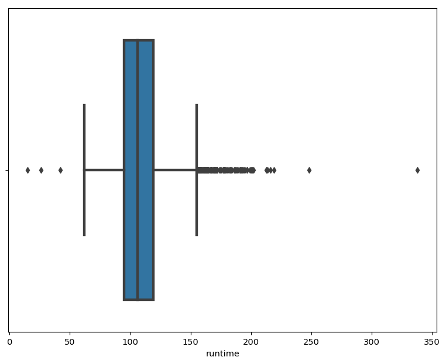

```python
import seaborn as sns
#The First plot is box plot of the runtime of the movies
plt.figure(figsize=(9,7), dpi = 105)

#using seaborn to generate the boxplot
sns.boxplot(tmdb_data['runtime'], linewidth = 3)
#diplaying the plot
plt.show()
```

### Plotting data point

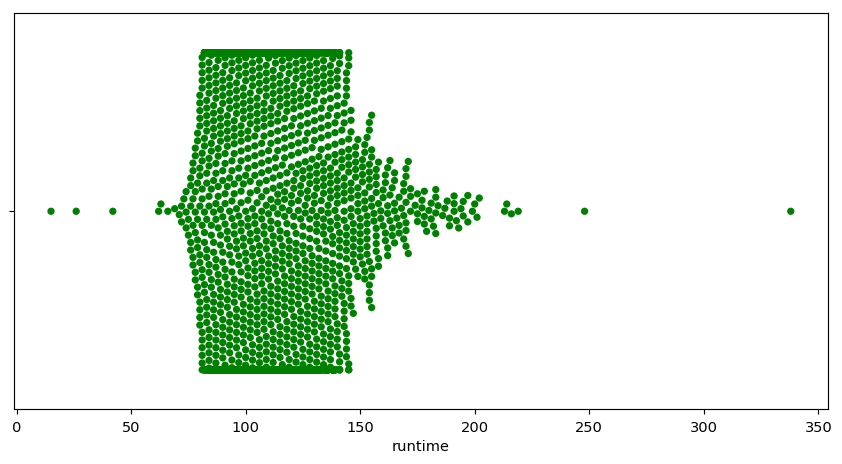

```python
#The Second plots is the data points plot of runtime of movies
import seaborn as sns
plt.figure(figsize=(10,5), dpi = 105)
#using seaborn to generate the plot
sns.swarmplot(tmdb_data['runtime'], color = 'green')
#displaying the plot
plt.show()
```

```python
#getting specific runtime
tmdb_data['runtime'].describe()
```

```
count    3855.000000
mean      109.215824
std        19.922166
min        15.000000
25%        95.000000
50%       106.000000
75%       119.000000
max       338.000000
Name: runtime, dtype: float64
```

The plot generated above give a visual of complete distribution of runtime of movies by plotting the points againts their respective position in the ditribution

first plot,ie box-plot gives us an overall idea of how spreaded the ditribution is in case of runtime of the movies.

#### Conclusions from the box plot and data plot

By looking at both the plot and calculations, we can conclude that..

25% of movies have a runtime of less than 95 minutes

75% of movies have a runtime of less than 119 minutes

**Popularity:**

We can determine over the years, what is the likely rating a movie will receive

Accordingly, we use a histogram to observe the counts of popularity from our new dataset

Maximum counts will reflect the typical popularity rating of movies

```python
#determining average popularity of the movies
avg_fun('popularity')
```

```
1.19139971465629
```

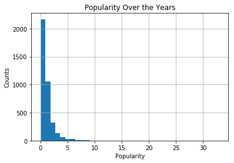

```python
#Exploring popularity variable over the years to determine typical ratings by audiences
tmdb_data['popularity'].hist(bins=36)
plt.xlabel('Popularity')
plt.ylabel('Counts')
plt.title('Popularity Over the Years');
```

```python
# We wish to determine if over the years, there is typical popularity rating
# We use the function describe to double check the numerical values seen in above plot

tmdb_data['popularity'].describe()
```

```
count    3855.000000
mean        1.191400
std         1.475002
min         0.001117
25%         0.462448
50%         0.797298
75%         1.368245
max        32.985763
Name: popularity, dtype: float64
```

**Observations about Popularity Ratings**:

The distribution is skewed to right.

**Revenue:** We wish to determine if over the years, what is the likely revenue a movie will generate

Accordingly, we use a histogram to observe the counts of revenues from our dataset

Maximum counts will reflect the typical revenue earned by movies

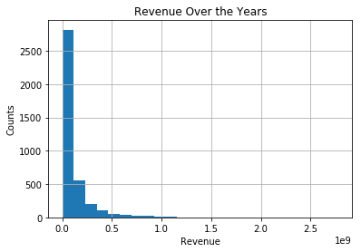

```python
#Exploring revenue variable over the years to determine typical revenues grossed by the movies
tmdb_data['revenue'].hist(bins=24)
plt.xlabel('Revenue')
plt.ylabel('Counts')
plt.title('Revenue Over the Years');
```

```python
# We wish to determine if over the years, there is typical revenue received
# We use the function describe to double check the numerical values seen in above plot

tmdb_data['revenue'].describe()
```

```
count    3.855000e+03
mean     1.076589e+08
std      1.765248e+08
min      2.000000e+00
25%      1.357645e+07
50%      4.479322e+07
75%      1.241530e+08
max      2.781506e+09
Name: revenue, dtype: float64
```

### Research Question 6 (2D Exploration: Year of release vs Profitability)

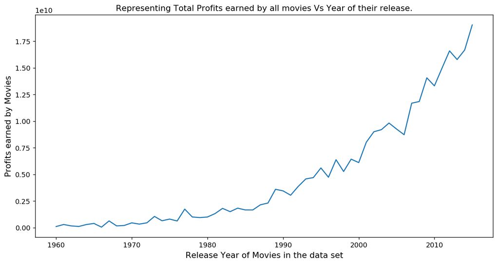

```python
#We will be using Line plot for this analysis
#Since we want to know the profits of movies for every year therefore we have to sum up all the movies of a particular year

profits_year = tmdb_data.groupby('release_year')['profit_earned'].sum()

#figure size(width, height)
plt.figure(figsize=(12,6), dpi = 130)

#on x-axis
plt.xlabel('Release Year of Movies in the data set', fontsize = 12)
#on y-axis
plt.ylabel('Profits earned by Movies', fontsize = 12)
#title of the line plot
plt.title('Representing Total Profits earned by all movies Vs Year of their release.')

#plotting the graph
plt.plot(profits_year)

#displaying the line plot
plt.show()
```

```python
#To find that which year made the highest profit?
profits_year.idxmax()
#profits_year.head()
```

```
2015
```

So from code and graph we can conclude 2015 made highest profit

Till this point we can conclude analysing the given data set. Next we are going to predict or analyse characteristics of a particular subset of movies like profitable movies

With Respect to profitable movies we can predict some features trends . Fixing profit to 50 million dollar we consider only those movies

```python
#selecting the movies having profit $50M or more
profit_data = tmdb_data[tmdb_data['profit_earned'] >= 50000000]

#reindexing new data
profit_data.index = range(len(profit_data))

#we will start from 1 instead of 0
profit_data.index = profit_data.index + 1

#printing the changed dataset
profit_data.head(3)
```

|  | popularity | budget | profit_earned | revenue | original_title | cast | director | tagline | runtime | genres | production_companies | release_date | vote_count | vote_average | release_year | budget_adj | revenue_adj |
| --- | --- | --- | --- | --- | --- | --- | --- | --- | --- | --- | --- | --- | --- | --- | --- | --- | --- |
| 1 | 32.985763 | 150000000 | 1363528810 | 1513528810 | Jurassic World | Chris Pratt\|Bryce Dallas Howard\|Irrfan Khan\|Vi... | Colin Trevorrow | The park is open. | 124 | Action\|Adventure\|Science Fiction\|Thriller | Universal Studios\|Amblin Entertainment\|Legenda... | 2015-06-09 | 5562 | 6.5 | 2015 | 1.379999e+08 | 1.392446e+09 |
| 2 | 28.419936 | 150000000 | 228436354 | 378436354 | Mad Max: Fury Road | Tom Hardy\|Charlize Theron\|Hugh Keays-Byrne\|Nic... | George Miller | What a Lovely Day. | 120 | Action\|Adventure\|Science Fiction\|Thriller | Village Roadshow Pictures\|Kennedy Miller Produ... | 2015-05-13 | 6185 | 7.1 | 2015 | 1.379999e+08 | 3.481613e+08 |
| 3 | 13.112507 | 110000000 | 185238201 | 295238201 | Insurgent | Shailene Woodley\|Theo James\|Kate Winslet\|Ansel... | Robert Schwentke | One Choice Can Destroy You | 119 | Adventure\|Science Fiction\|Thriller | Summit Entertainment\|Mandeville Films\|Red Wago... | 2015-03-18 | 2480 | 6.3 | 2015 | 1.012000e+08 | 2.716190e+08 |

```python
#counting the no.of rows in the new data base
len(profit_data)
```

```
1338
```

### Research Question 7 (2D Exploration: Runtime vs Profitability)

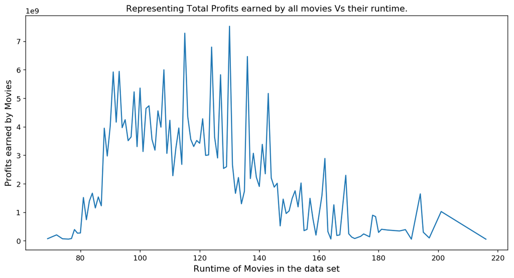

```python
#We will be using Line plot for this analysis
#Since we want to know the profits of movies for every year therefore we have to sum up all the movies of a particular year

profits_runtime = profit_data.groupby('runtime')['profit_earned'].sum()

#figure size(width, height)
plt.figure(figsize=(12,6), dpi = 130)

#on x-axis
plt.xlabel('Runtime of Movies in the data set', fontsize = 12)
#on y-axis
plt.ylabel('Profits earned by Movies', fontsize = 12)
#title of the line plot
plt.title('Representing Total Profits earned by all movies Vs their runtime.')

#plotting the graph
plt.plot(profits_runtime)

#displaying the line plot
plt.show()
```

```python
#runtime of the most successful genres

profits_runtime.max()
```

```
7527235982
```

#### Successful Genres

```python
#function which will take any column as argument from and keep its track
def data(column):
    #will take a column, and separate the string by '|'
    data = profit_data[column].str.cat(sep = '|')

    #giving pandas series and storing the values separately
    data = pd.Series(data.split('|'))

    #arranging in descending order
    count = data.value_counts(ascending = False)

    return count
```

```python
#variable to store the retured value
count = data('genres')
#printing top 5 values
count.head()
```

```
Comedy       492
Drama        481
Action       464
Thriller     405
Adventure    379
dtype: int64
```

```python
#Lets to a graphical analysis of the above collected data.
#lets plot the points in descending order top to bottom as we have data in same format.
count.sort_values(ascending = True, inplace = True)
```

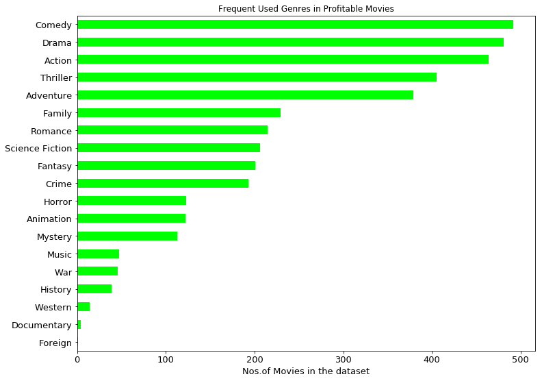

```python
#ploting
lt = count.plot.barh(color = '#00FF00', fontsize = 13)
#title
lt.set(title = 'Frequent Used Genres in Profitable Movies')

# on x axis
lt.set_xlabel('Nos.of Movies in the dataset', color = 'black', fontsize = '13')

#figure size(width, height)
lt.figure.set_size_inches(12, 9)

#ploting the graph
plt.show()
```

```python
#using correlation to determine factors influencing revenues
tmdb_data.corr(method='pearson')
```

|  | popularity | budget | profit_earned | revenue | runtime | vote_count | vote_average | release_year | budget_adj | revenue_adj |
| --- | --- | --- | --- | --- | --- | --- | --- | --- | --- | --- |
| popularity | 1.000000 | 0.446993 | 0.596224 | 0.615556 | 0.215157 | 0.780106 | 0.317924 | 0.173179 | 0.399375 | 0.546985 |
| budget | 0.446993 | 1.000000 | 0.526815 | 0.688548 | 0.260989 | 0.556939 | 0.024227 | 0.267984 | 0.958518 | 0.533497 |
| profit_earned | 0.596224 | 0.526815 | 1.000000 | 0.979135 | 0.220352 | 0.728366 | 0.259599 | 0.087826 | 0.502139 | 0.906421 |
| revenue | 0.615556 | 0.688548 | 0.979135 | 1.000000 | 0.250398 | 0.754583 | 0.227279 | 0.139001 | 0.657577 | 0.900892 |
| runtime | 0.215157 | 0.260989 | 0.220352 | 0.250398 | 1.000000 | 0.273842 | 0.351909 | -0.112607 | 0.334011 | 0.280604 |
| vote_count | 0.780106 | 0.556939 | 0.728366 | 0.754583 | 0.273842 | 1.000000 | 0.387271 | 0.207073 | 0.497988 | 0.654713 |
| vote_average | 0.317924 | 0.024227 | 0.259599 | 0.227279 | 0.351909 | 0.387271 | 1.000000 | -0.134493 | 0.036913 | 0.266996 |
| release_year | 0.173179 | 0.267984 | 0.087826 | 0.139001 | -0.112607 | 0.207073 | -0.134493 | 1.000000 | 0.075032 | -0.103260 |
| budget_adj | 0.399375 | 0.958518 | 0.502139 | 0.657577 | 0.334011 | 0.497988 | 0.036913 | 0.075032 | 1.000000 | 0.570466 |
| revenue_adj | 0.546985 | 0.533497 | 0.906421 | 0.900892 | 0.280604 | 0.654713 | 0.266996 | -0.103260 | 0.570466 | 1.000000 |

From, the above correlation answers, we can see that : revenue is correlated positively with popularity and vote counts

### Revenue Vs Popularity

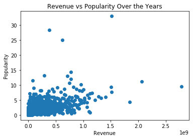

```python
# Creating a scatterplot of revenue and popularity over the years
plt.scatter(x=tmdb_data['revenue'], y=tmdb_data['popularity'])
plt.xlabel('Revenue')
plt.ylabel('Popularity')
plt.title('Revenue vs Popularity Over the Years');
```

**Observations:**

From this we can observe that Revenue is positively correlated with Popularity

Few outliers that are extremely high shpuld be considered

Revenue increased with popularity

**Revenue vs Vote counts:**

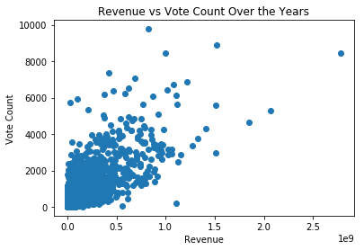

```python
# Creating a scatterplot of revenue and vote counts over the years
plt.scatter(x=tmdb_data['revenue'], y=tmdb_data['vote_count'])
plt.xlabel('Revenue')
plt.ylabel('Vote Count')
plt.title('Revenue vs Vote Count Over the Years');
```

**Observations- Revenue vs Vote Count:**

The correlation computed from function is evident in the scatterplot.

Vote count is roughly proportional to revenues.

Even in this plot, we observe that a few sample had high counts but did not gross commensurately in revenue.

This plot points us to scrutinize the vote counts and type of votes if possible or any other factors influencing voting such as genres, cast, etc.

## Conclusions

After the analysis we found out that , for a movie to be successful

Year 2015 made highest profit.

Genre must be : Action, Adventure, Thriller, Comedy, Drama.

## Limitations

The data given may not be completely accurately

The data considered is only for profitable movies over 50 million dollars

Budget and revenue currency units might change with country